$\text{Michael Higgins}$

# $$\text{Lab 1:}$$

### A Little Statistics:

### 1).

#### Part A:

I looked it up, very nice!

#### Part B:

```python
import numpy as np
import scipy as sp
from scipy import stats
from scipy import special
import matplotlib.pyplot as plt
```

```python
for x, value in enumerate(range(-3,4)):
    print ('Sigma = {0:d}       Probablility = {1:f}'.format((x-3),stats.norm.cdf(value)))
```

```
Sigma = -3       Probablility = 0.001350
Sigma = -2       Probablility = 0.022750
Sigma = -1       Probablility = 0.158655
Sigma = 0       Probablility = 0.500000
Sigma = 1       Probablility = 0.841345
Sigma = 2       Probablility = 0.977250
Sigma = 3       Probablility = 0.998650
```

These match the Z-table on Wolfram

#### Part C:

Using the probabilities from above we get...

```python
#Creating my list of known probabilities
prob = np.asarray([])
for x in range(-3,4):
    prob = np.insert(prob,x+3,stats.norm.cdf(x))
```

```python
for x, value in enumerate(prob):
    print ('Known Probabilities = {0:f}       Associated Sigma = {1:f}'.format(prob[x],stats.norm.ppf(value)))
```

```
Known Probabilities = 0.001350       Associated Sigma = -3.000000
Known Probabilities = 0.022750       Associated Sigma = -2.000000
Known Probabilities = 0.158655       Associated Sigma = -1.000000
Known Probabilities = 0.500000       Associated Sigma = 0.000000
Known Probabilities = 0.841345       Associated Sigma = 1.000000
Known Probabilities = 0.977250       Associated Sigma = 2.000000
Known Probabilities = 0.998650       Associated Sigma = 3.000000
```

#### Part D:

The negative value that appears for the $\sigma$ arises from whether a value is less than the mean of the guassian distributed pdf.

### 2).

#### Part A:

I read about the exponential distribution, very nice. Thank you.

#### Part B:

$$ PDF_{exp}(x)= \left\{ \begin{array}{ll} \lambda e^{-\lambda x} & x\geq 0 \\ 0 & x < 0 \\ \end{array} \right. $$

```python
#Analytic
x = np.linspace(0,5,1000)
def findy(l):
    y = l*np.e**(-l*x)
    return y

#Simulated Data

data = stats.expon.rvs(size=100000)
```

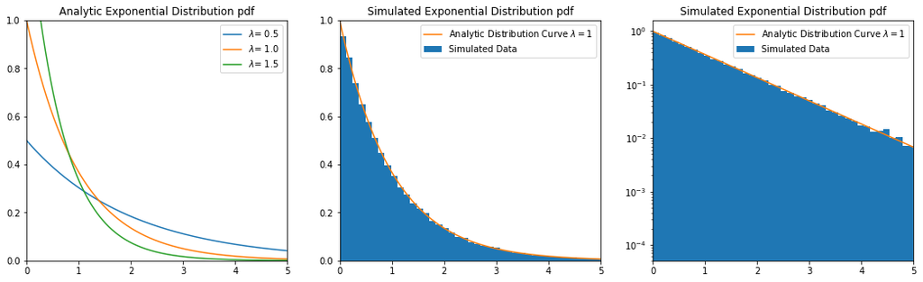

```python
#Setting up a figure
fig , ax = plt.subplots(1,3,figsize=(18,5))

#Plotting the exponential function analytically for different values of lambda
for z in range(1,4):
    ax[0].plot(x,findy(z/2),label=r"$\lambda$= {0:.1f}".format(z/2))
ax[0].legend()
ax[0].set_xlim(0,5)
ax[0].set_ylim(0,1)
ax[0].set_title("Analytic Exponential Distribution pdf")

#Making a histagram for the simulated distribution with lambda =1
ax[1].hist(data,bins=100,density='true',label ="Simulated Data")
ax[1].set_xlim(0,5)
ax[1].set_ylim(0,1)
ax[1].set_title("Simulated Exponential Distribution pdf")
ax[1].plot(x,findy(1),label = r'Analytic Distribution Curve $\lambda =1$')
ax[1].legend();

#Plotting the log
ax[2].hist(data,bins=100,density='true',label ="Simulated Data")
ax[2].set_title("Simulated Exponential Distribution pdf")
ax[2].plot(x,findy(1),label = r'Analytic Distribution Curve $\lambda =1$')
ax[2].set_yscale('log')
ax[2].set_xlim(0,5)
ax[2].legend();
```

### 3).

#### Part A:

I choose the value 4.

#### Part B:

What is the probability of getting a signal free value of 4 from a background that is an exponential distrubution with a mean equal to $\frac{1}{\lambda} = 1$?

#### Part C:

$$P = \int_{4}^{\infty}\lambda e^{-\lambda x}dx$$

#### Part D:

```python
print('The probability that the background produced a value greater than 4 is {0:f}'.format(1-stats.expon.cdf(4)))
```

```
The probability that the background produced a value greater than 4 is 0.018316
```

#### Part E:

$$2 \cdot erf^{-1} \left( \int_{4}^{\infty}\lambda e^{-\lambda x} dx \right) = X$$

Where $erf^{-1}$ is the inverse error function and $X$ corresponds to the number of sigmas.

```python
X = stats.norm.ppf(stats.expon.cdf(4))
X
```

```
2.0898499829712565
```

The associated Sigma value is $\approx$ 2.09 $\sigma$

### 4).

```python
for x in range(3,11):
    print('The probability that the background produced a value greater than {0:d} is {1:f}'.format(x,1-stats.expon.cdf(x)))
```

```
The probability that the background produced a value greater than 3 is 0.049787
The probability that the background produced a value greater than 4 is 0.018316
The probability that the background produced a value greater than 5 is 0.006738
The probability that the background produced a value greater than 6 is 0.002479
The probability that the background produced a value greater than 7 is 0.000912
The probability that the background produced a value greater than 8 is 0.000335
The probability that the background produced a value greater than 9 is 0.000123
The probability that the background produced a value greater than 10 is 0.000045
```

```python
t = np.asarray([])
for x in range(3,20):
    t = np.insert(t,x-3,stats.expon.cdf(x))
```

```python
for x in range(3,20):
    print('The probability that the background produced a value greater than {0:d} is {1:f} sigma'.format(x,stats.norm.ppf(t[x-3])))
```

```
The probability that the background produced a value greater than 3 is 1.646922 sigma
The probability that the background produced a value greater than 4 is 2.089850 sigma
The probability that the background produced a value greater than 5 is 2.470939 sigma
The probability that the background produced a value greater than 6 is 2.809782 sigma
The probability that the background produced a value greater than 7 is 3.117525 sigma
The probability that the background produced a value greater than 8 is 3.401193 sigma
The probability that the background produced a value greater than 9 is 3.665538 sigma
The probability that the background produced a value greater than 10 is 3.913946 sigma
The probability that the background produced a value greater than 11 is 4.148929 sigma
The probability that the background produced a value greater than 12 is 4.372407 sigma
The probability that the background produced a value greater than 13 is 4.585886 sigma
The probability that the background produced a value greater than 14 is 4.790573 sigma
The probability that the background produced a value greater than 15 is 4.987453 sigma
The probability that the background produced a value greater than 16 is 5.177341 sigma
The probability that the background produced a value greater than 17 is 5.360921 sigma
The probability that the background produced a value greater than 18 is 5.538772 sigma
The probability that the background produced a value greater than 19 is 5.711392 sigma
```

I see that as the event becomes less likely to be caused by the background distribution the sigma value increases. This increase in sigma seems to get smaller as the value increases.

### Non-continuous Distributions

### 1).

#### Part A:

I am doing the Binomial Dsitribution.

#### Part B:

$$\text{Binomial PMF} = \left( \begin{array}{11} n \\ k \end{array}\right) P^k (1-P)^{n-k}$$

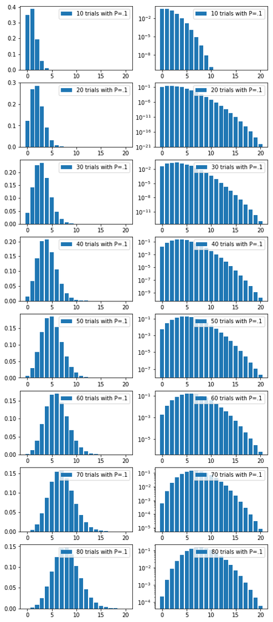

```python
fig,ax = plt.subplots(8,2,figsize=(8,20))
k = np.linspace(0,20,21)
for j in range(0,8):
    ax[j][0].bar(k,stats.binom.pmf(k,(j+1)*10,.1),label = "{0:d} trials with P=.1".format((j+1)*10))
    ax[j][0].legend()

for j in range(0,8):
    ax[j][1].bar(k,stats.binom.pmf(k,(j+1)*10,.1),label = "{0:d} trials with P=.1".format((j+1)*10))
    ax[j][1].legend()
    ax[j][1].set_yscale('log')
```

#### Part C:

What is the probability that a signal-free background with a Binomial probability mass distribution(Probability of success = .1) will have 5 successes after 80 trials?

```python
print('Probability of 5 successes is {0:.5f}%'.format(100*stats.binom.pmf(5,80,.1)))
```

```
Probability of 5 successes is 8.89453%
```

#### Part D:

This just means that for experiments that are looking for discrete counts -like the number of gamma rays detected- we can find the exact probability that 10 gamma rays are expected to be detected given a particular discrete background probability mass distribution. Where for a pdf we would also have a probability of 10.1 gamma rays being detected and this would not make sense given the experiment.

#### Part E:

This makes sense because the mean is a sum of the number of counts multiplied by their respective probabilities. This results in a value that is continuous rather than discrete. Things that remain discrete are the probability of individual numbers of counts. This is because these values depend on context of the experiment, the probability of getting a certain number of counts will always be discrete because the experiment is directly measuring a binary answer to that question. The mean on the other hand is a result of averaging over all of the successes of the experiment and this number depends on how many trials there had been conducted.